# Lab 06: Tree-based methods

# Regression trees with Growth Data

```r
library(tree)
?tree()
```

```
## Help on topic 'tree' was found in the following packages:
##
##   Package               Library
##   cli                   /Library/Frameworks/R.framework/Versions/4.1/Resources/library
##   tree                  /Library/Frameworks/R.framework/Versions/4.1/Resources/library
##   xfun                  /Library/Frameworks/R.framework/Versions/4.1/Resources/library
##
##
## Using the first match ...
```

```r
library(hdm)
names(GrowthData)
```

```
##  [1] "Outcome"   "intercept" "gdpsh465"  "bmp1l"     "freeop"    "freetar"
##  [7] "h65"       "hm65"      "hf65"      "p65"       "pm65"      "pf65"
## [13] "s65"       "sm65"      "sf65"      "fert65"    "mort65"    "lifee065"
## [19] "gpop1"     "fert1"     "mort1"     "invsh41"   "geetot1"   "geerec1"
## [25] "gde1"      "govwb1"    "govsh41"   "gvxdxe41"  "high65"    "highm65"
## [31] "highf65"   "highc65"   "highcm65"  "highcf65"  "human65"   "humanm65"
## [37] "humanf65"  "hyr65"     "hyrm65"    "hyrf65"    "no65"      "nom65"
## [43] "nof65"     "pinstab1"  "pop65"     "worker65"  "pop1565"   "pop6565"
## [49] "sec65"     "secm65"    "secf65"    "secc65"    "seccm65"   "seccf65"
## [55] "syr65"     "syrm65"    "syrf65"    "teapri65"  "teasec65"  "ex1"
## [61] "im1"       "xr65"      "tot1"
```

Let’s drop the intercept

```r
GData=GrowthData[,-2]
names(GData)
```

```
##  [1] "Outcome"  "gdpsh465" "bmp1l"    "freeop"   "freetar"  "h65"
##  [7] "hm65"     "hf65"     "p65"      "pm65"     "pf65"     "s65"
## [13] "sm65"     "sf65"     "fert65"   "mort65"   "lifee065" "gpop1"
## [19] "fert1"    "mort1"    "invsh41"  "geetot1"  "geerec1"  "gde1"
## [25] "govwb1"   "govsh41"  "gvxdxe41" "high65"   "highm65"  "highf65"
## [31] "highc65"  "highcm65" "highcf65" "human65"  "humanm65" "humanf65"
## [37] "hyr65"    "hyrm65"   "hyrf65"   "no65"     "nom65"    "nof65"
## [43] "pinstab1" "pop65"    "worker65" "pop1565"  "pop6565"  "sec65"
## [49] "secm65"   "secf65"   "secc65"   "seccm65"  "seccf65"  "syr65"
## [55] "syrm65"   "syrf65"   "teapri65" "teasec65" "ex1"      "im1"
## [61] "xr65"     "tot1"
```

### Regression tree for growth rates

Let’s grow a tree

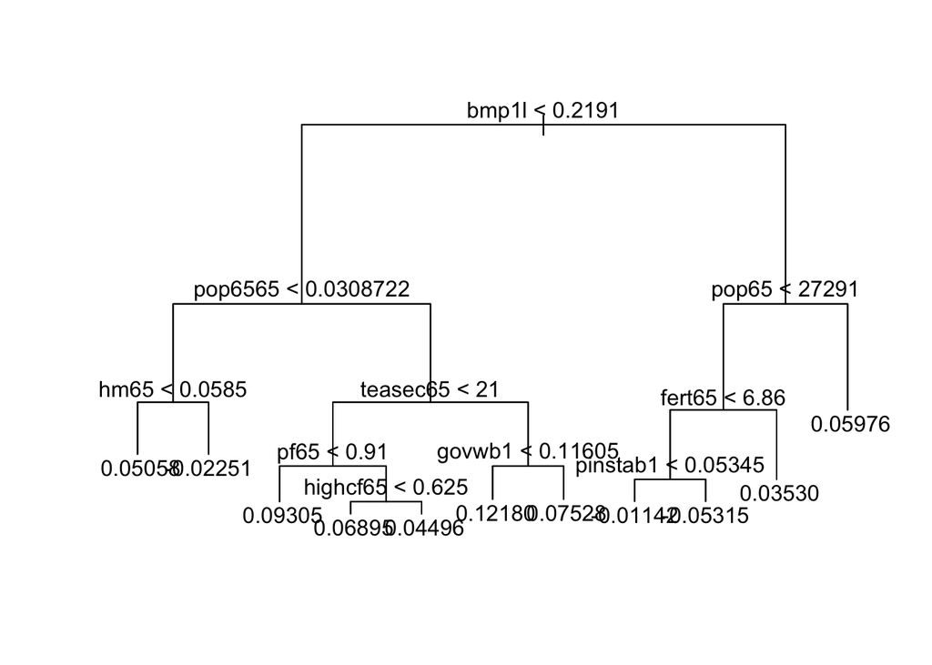

```r
Gtree=tree(Outcome~.,GData)
plot(Gtree)
text(Gtree)
```

Summary:

```r
summary(Gtree)
```

```
##
## Regression tree:
## tree(formula = Outcome ~ ., data = GData)
## Variables actually used in tree construction:
##  [1] "bmp1l"    "pop6565"  "hm65"     "teasec65" "pf65"     "highcf65"
##  [7] "govwb1"   "pop65"    "fert65"   "pinstab1"
## Number of terminal nodes:  11
## Residual mean deviance:  0.0007798 = 0.06161 / 79
## Distribution of residuals:
##     Min.  1st Qu.   Median     Mean  3rd Qu.     Max.
## -0.07848 -0.01430 -0.00383  0.00000  0.01459  0.11330
```

- The initial GDP is dropped! The tree thinks it’s not a useful predictor.
- Only 10 variables out of over 60 used.
- There are 11 leaves

##### Pruning

- A tree can have a high variance if there are many leaves and few observations in every leaf.
- Pruning removes branches with all their leaves to reduce the number of leaves.
- We can use a penalized SSR to decide how many leaves to keep.

$$\begin{align}
&\sum_{m=1}^{|T|}\sum_{X_i\in \mathcal{N}_m}(Y_i-\hat Y_{\mathcal{N}_m})^2+\alpha |T|,\quad \text{where}\\
\hat Y_{\mathcal{N}_m} &=\frac{1}{|\mathcal{N}_m|}\sum_{X_i\in \mathcal{N}_m} Y_i.
\end{align}$$

- $T$ is the number of leaves.
- Leaves: $\mathcal{N}_m$, $m=1,\ldots,|T|$.
- $\hat Y_{\mathcal{N}_m}$ is the average of $Y$’s in the $m$-th leaf.
- $\alpha$ is the cost complexity parameter.

Cross validation to select the cost complexity parameter.

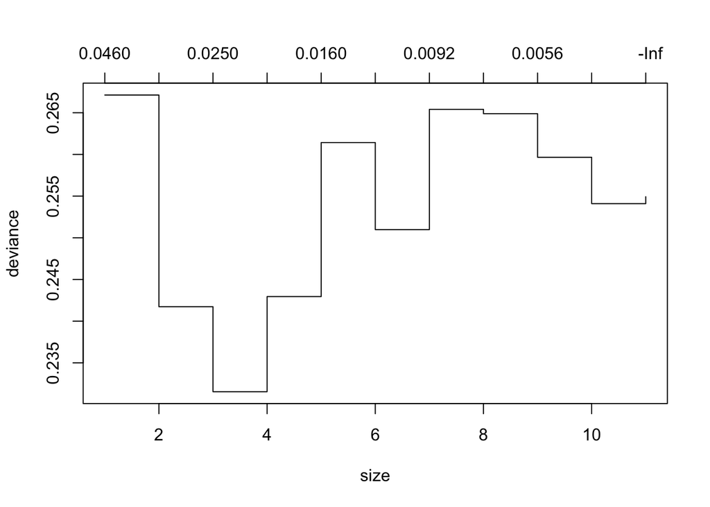

```r
set.seed(1,sample.kind = "Rejection")
cv.Gtree=cv.tree(Gtree)
plot(cv.Gtree)
```

We’ll use the smaller tree with the best deviance (SSR):

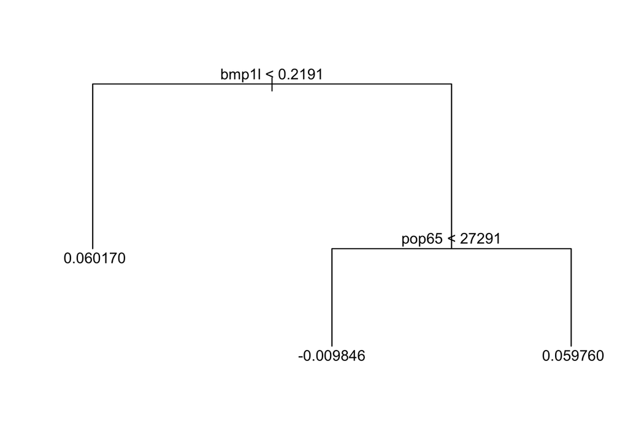

```r
Pruned.Gtree=prune.tree(Gtree,best=3)
plot(Pruned.Gtree)
text(Pruned.Gtree)
```

There are only two selected factors:

- Black-market premium
- Population over 65

```r
names(Pruned.Gtree)
```

```
## [1] "frame"   "where"   "terms"   "call"    "y"       "weights"
```

We can see the resulting partition of the sample:

```r
Pruned.Gtree
```

```
## node), split, n, deviance, yval
##       * denotes terminal node
##
## 1) root 90 0.23430  0.045350
##   2) bmp1l < 0.2191 63 0.11030  0.060170 *
##   3) bmp1l > 0.2191 27 0.07793  0.010780
##     6) pop65 < 27291 19 0.03362 -0.009846 *
##     7) pop65 > 27291 8 0.01703  0.059760 *
```

`$where` indicates the leaf for each observation

```r
table(Pruned.Gtree$where)
```

```
##
##  2  4  5
## 63 19  8
```

##### Any relationship to the initial GDP?

We summarize the initial GDP per capita, Outcome, and the number of obs by leaf using:

- `aggregate(x,by,FUN)`
- `x=` a variable/object to summarize.
- `by=` a grouping variable (leaf in our case).
- `FUN=` a function to apply (e.g. “mean”, “sum”, “length”).

```r
Initial<-aggregate(x=GData$gdpsh465,by=list(Pruned.Gtree$where),FUN="mean")
Growth<-aggregate(x=GData$Outcome,by=list(Pruned.Gtree$where),FUN="mean")
Number<-aggregate(x=GData$Outcome,by=list(Pruned.Gtree$where),FUN="length")
```

Format using the table

```r
library(kableExtra)
cbind(Leaf=c("low black market premium","high black market premium, low pop. over 65", "high black market premium, high pop. over 65" ),data.frame(Number,Initial[,2],Growth[,2])) %>%
  kable(digits=2,
        col.names=c("Leaf description","Leaf", "Number of countries","Initial GDP per capita", "Growth rate")) %>%
  kable_classic(full_width = F, html_font = "Cambria")
```

| Leaf description | Leaf | Number of countries | Initial GDP per capita | Growth rate |
| --- | --- | --- | --- | --- |
| low black market premium | 2 | 63 | 8.01 | 0.06 |
| high black market premium, low pop. over 65 | 4 | 19 | 7.16 | -0.01 |
| high black market premium, high pop. over 65 | 5 | 8 | 6.56 | 0.06 |

No clear relationship:

- The highest and lowest initial GDP correspond to the same rate.
- The middle initial GDP corresponds to a negative growth rate.
- This is a forecasting exercise: no structure here.

### Out of sample prediction with regression trees

Select 60 observations into a training sample:

```r
set.seed(6064,sample.kind="Reject")
Gtrain=sample(1:nrow(GData),60)
```

Let’s fit a tree on the training sample:

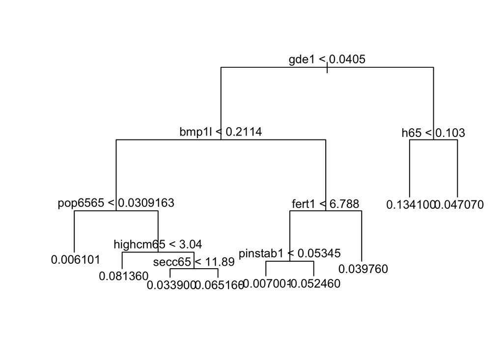

```r
Ttrain=tree(Outcome~. ,GData,subset=Gtrain)
plot(Ttrain)
text(Ttrain)
```

- Note that a different variable is now selected at the root!
  - Government spending on defense.
  - Pruning won’t eliminate it!
- Black-market premium is still high up the tree.

Cross validation for pruning:

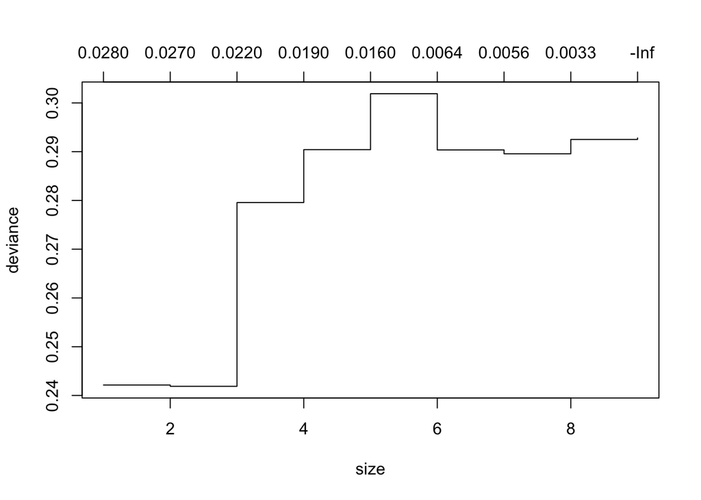

```r
set.seed(42,sample.kind="Reject")
CVTtrain=cv.tree(Ttrain)
plot(CVTtrain)
```

Pruning:

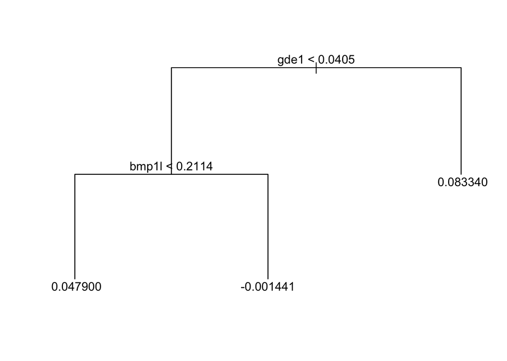

```r
PTtrain=prune.tree(Ttrain,best=3)
plot(PTtrain)
text(PTtrain)
```

- A different tree from the full sample!
  - High defense spending now predicts high growth rates!
  - Correlations - no causality.
- Tree-based methods have a high variance.
- Dropping some observations can result in a very different tree!

The outcome variable in the test sample:

```r
outcome.test=GData$Outcome[-Gtrain]
```

Predict out of sample:

```r
predtree=predict(PTtrain,newdata=GData[-Gtrain,])
```

The MSE for the prediction error as a fraction of the variance:

```r
MSE.out.G.tree<-mean((predtree-outcome.test)^2)/var(outcome.test)
MSE.out.G.tree
```

```
## [1] 0.9839248
```

##### Let’s compare with Lasso

```r
library(glmnet)
GXtrain<-model.matrix(Outcome~.,data=GData[Gtrain,])[,-1]
GYtrain<-GData$Outcome[Gtrain]
set.seed(42,sample.kind="Reject")
CV.lasso<-cv.glmnet(GXtrain,GYtrain,alpha=1)
coef(CV.lasso,s=CV.lasso$lambda.min)
```

```
## 62 x 1 sparse Matrix of class "dgCMatrix"
##                        s1
## (Intercept)  2.507215e-02
## gdpsh465    -1.351225e-02
## bmp1l       -6.544202e-02
## freeop       1.052178e-01
## freetar      .
## h65          .
## hm65         .
## hf65        -1.042503e-01
## p65          .
## pm65         1.109255e-01
## pf65         .
## s65          .
## sm65         .
## sf65        -4.237631e-02
## fert65       .
## mort65       .
## lifee065     .
## gpop1       -2.399056e-01
## fert1        .
## mort1       -2.337037e-01
## invsh41      2.070109e-03
## geetot1      .
## geerec1     -7.145388e-01
## gde1         4.094251e-01
## govwb1       .
## govsh41      .
## gvxdxe41     .
## high65       .
## highm65      .
## highf65      .
## highc65      .
## highcm65     .
## highcf65     .
## human65      .
## humanm65     .
## humanf65     .
## hyr65        .
## hyrm65       .
```

[output cut: 9 more lines]

```
## sec65        .
## secm65       .
## secf65       .
## secc65       .
## seccm65      2.483588e-03
## seccf65      .
## syr65        .
## syrm65       .
## syrf65       .
## teapri65     1.210389e-03
## teasec65     9.237539e-05
## ex1          .
## im1          5.325215e-02
## xr65         2.354448e-05
## tot1        -1.063706e-01
```

- Lasso picked more predictors
- Black-market premium is also included!
- Defense spending is also included!

Lasso’s out of sample prediction error as a fraction of the variance:

```r
GXtest<-model.matrix(Outcome~.,data=GData[-Gtrain,])[,-1]
Glassopred<-predict(CV.lasso,s=CV.lasso$lambda.min,newx=GXtest)
MSE.out.G.lasso<-mean((Glassopred-outcome.test)^2)/var(outcome.test)
MSE.out.G.lasso
```

```
## [1] 1.248872
```

Summary:

```r
cbind(MSE.out.G.tree,MSE.out.G.lasso) %>%
  kable(digits=2,
        caption="Out of sample MSE for Growth Data",
        col.names=c("Tree","Lasso")) %>%
  kable_classic(full_width = F, html_font = "Cambria")
```

Out of sample MSE for Growth Data

| Tree | Lasso |
| --- | --- |
| 0.98 | 1.25 |

- The tree did better with fewer predictors!
  - Tree: A more flexible model.
  - Lasso: Linear-regression-type prediction.
- We did not do post-Lasso as out goal here is prediction.

# Classification trees with Rossi arrests data

```r
library(carData)
names(Rossi)
```

```
##  [1] "week"   "arrest" "fin"    "age"    "race"   "wexp"   "mar"    "paro"
##  [9] "prio"   "educ"   "emp1"   "emp2"   "emp3"   "emp4"   "emp5"   "emp6"
## [17] "emp7"   "emp8"   "emp9"   "emp10"  "emp11"  "emp12"  "emp13"  "emp14"
## [25] "emp15"  "emp16"  "emp17"  "emp18"  "emp19"  "emp20"  "emp21"  "emp22"
## [33] "emp23"  "emp24"  "emp25"  "emp26"  "emp27"  "emp28"  "emp29"  "emp30"
## [41] "emp31"  "emp32"  "emp33"  "emp34"  "emp35"  "emp36"  "emp37"  "emp38"
## [49] "emp39"  "emp40"  "emp41"  "emp42"  "emp43"  "emp44"  "emp45"  "emp46"
## [57] "emp47"  "emp48"  "emp49"  "emp50"  "emp51"  "emp52"
```

```r
?Rossi
```

Creating a factor dependent variable:

```r
Rossi$Arrested<-as.factor(ifelse(Rossi$arrest==1,"yes","no"))
table(Rossi$Arrested)
```

```
##
##  no yes
## 318 114
```

Let’s construct `Wks`: % of time unemployed before re-arrest or until the end of the period:

```r
N<-nrow(Rossi)
Rossi$Weeks_worked<-0
for (i in 1:N){
  last_week_col<-Rossi$week[i]+10 #last week before arrest column number
  for (j in 11:last_week_col){
  Rossi$Weeks_worked[i]<-Rossi$Weeks_worked[i]+(Rossi[i,j]=="yes")
  }
}
Rossi$Wks<-(Rossi$week-Rossi$Weeks_worked)/Rossi$week
```

```r
RData<-subset(Rossi,select=c(Arrested,fin,age,race,wexp,mar,paro,prio,educ,Wks))
```

Let’s fit a classification tree:

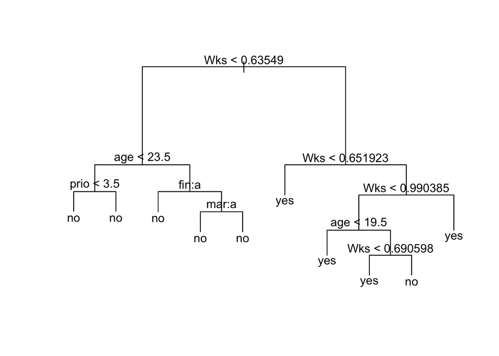

```r
Atree=tree(Arrested~.,RData)
plot(Atree)
text(Atree)
```

- `Wks` is at the root.

Let’s cross validate for pruning:

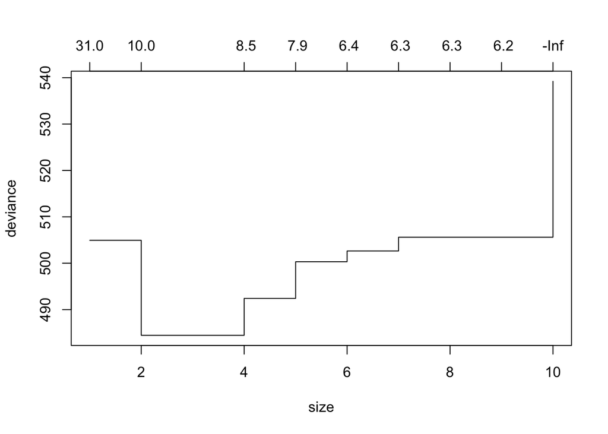

```r
set.seed(42,sample.kind="Reject")
CV.Atree=cv.tree(Atree)
plot(CV.Atree)
```

```r
CV.Atree
```

```
## $size
## [1] 10  9  8  7  6  5  4  2  1
##
## $dev
## [1] 539.2107 505.6079 505.6079 505.6079 502.6414 500.3246 492.4165 484.4610
## [9] 504.9401
##
## $k
## [1]      -Inf  6.200764  6.258047  6.316525  6.374226  7.908415  8.467290
## [8] 10.332250 30.972896
##
## $method
## [1] "deviance"
##
## attr(,"class")
## [1] "prune"         "tree.sequence"
```

Selection of the best tree size:

```r
RBest_size_ind=which(CV.Atree$dev==min(CV.Atree$dev))
RBest_size=CV.Atree$size[RBest_size_ind]
RBest_size
```

```
## [1] 2
```

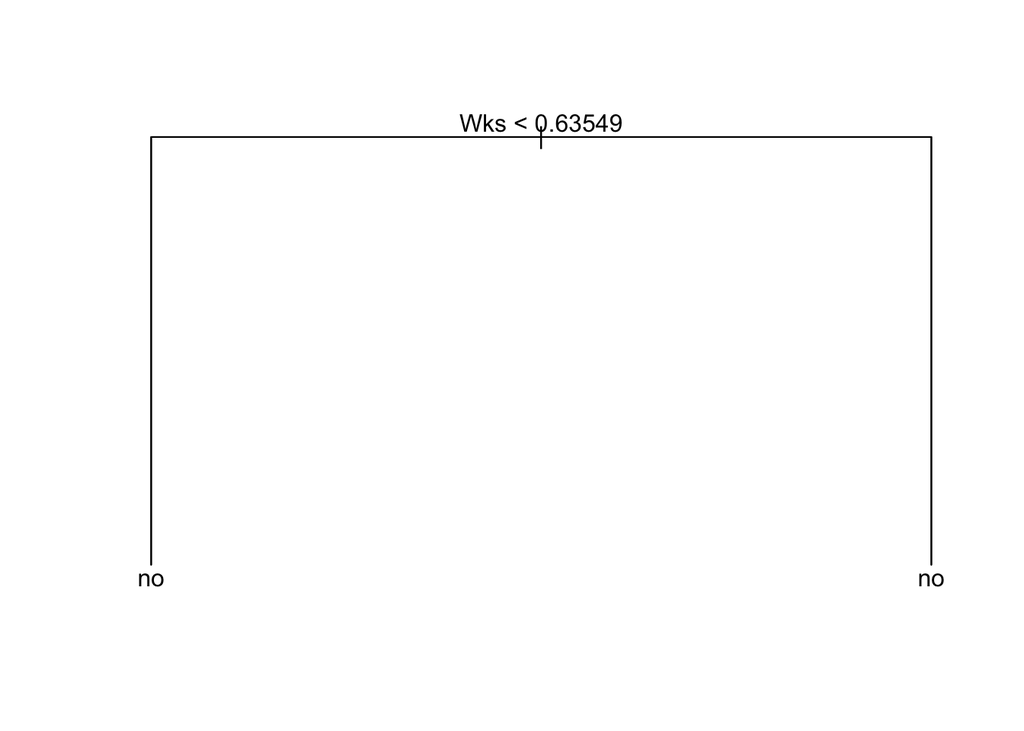

```r
PAtree=prune.tree(Atree,best=RBest_size)
plot(PAtree)
text(PAtree)
```

- The only factor that matters is % of time unemployed.
- A simple rule.

Let’s compare with Lasso:

```r
RX=model.matrix(Arrested~.,data=RData)[,-1]
Ry=RData$Arrested
CV.Alasso=cv.glmnet(RX,Ry,family="binomial",alpha=1)
coef(CV.Alasso,s=CV.Alasso$lambda.min)
```

```
## 10 x 1 sparse Matrix of class "dgCMatrix"
##                         s1
## (Intercept)    -0.26445690
## finyes         -0.23227428
## age            -0.04298614
## raceother      -0.12407000
## wexpyes         .
## marnot married  0.06909242
## paroyes         .
## prio            0.06112466
## educ           -0.17438078
## Wks             1.23908477
```

- More factors selected

### Out of sample

```r
nrow(RData)
```

```
## [1] 432
```

We’ll put aside 132 observations for evaluation:

```r
set.seed(6083,sample.kind="Reject")
Rtrain<-sample(1:nrow(RData),432-132)
```

Let’s fit on the training sample:

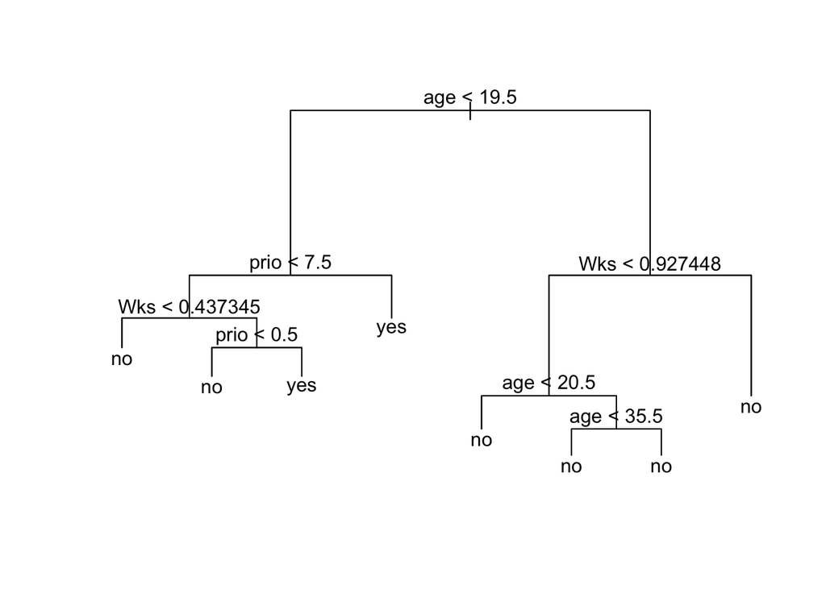

```r
Atree.train<-tree(Arrested~.,RData[Rtrain,])
plot(Atree.train)
text(Atree.train)
```

Cross validation:

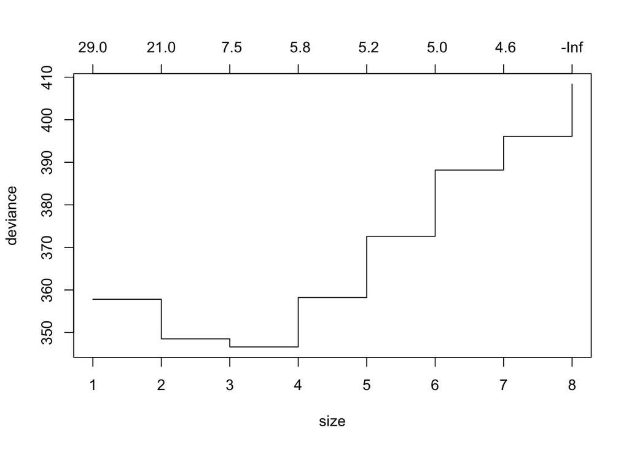

```r
set.seed(42,sample.kind="Reject")
CV.Atree.train<-cv.tree(Atree.train)
plot(CV.Atree.train)
```

Best size:

```r
CV.Atree.train$size[which(CV.Atree.train$dev==min(CV.Atree.train$dev))]
```

```
## [1] 3
```

- We pick the smallest tree that gives the best fit

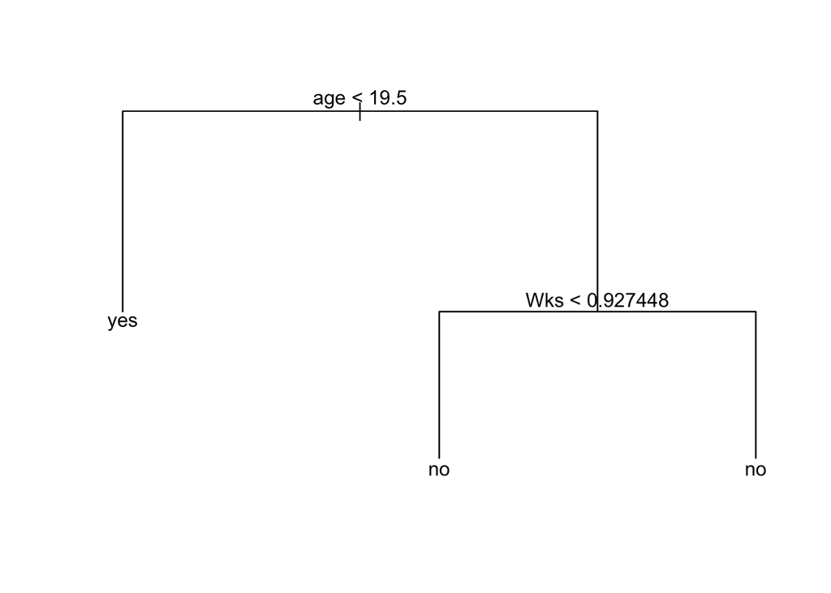

```r
PAtree.train<-prune.tree(Atree.train,best=3)
plot(PAtree.train)
text(PAtree.train)
```

Predict out of sample:

```r
predArrest=predict(PAtree.train,newdata=RData[-Rtrain,],type="class")
```

- Note the option `type="class"`

Compare with the truth:

```r
TAB<-table(predicted=predArrest,true=RData$Arrested[-Rtrain])
TAB
```

```
##          true
## predicted no yes
##       no  86  27
##       yes 15   4
```

The error rate:

```r
Error.prunned<-(TAB[1,2]+TAB[2,1])/sum(TAB)
Error.prunned
```

```
## [1] 0.3181818
```

##### Compare with Lasso

```r
AXtrain<-model.matrix(Arrested~.,data=RData[Rtrain,])[,-1]
Aytrain<-RData$Arrested[Rtrain]
set.seed(42,sample.kind="Reject")
ACV.lasso<-cv.glmnet(AXtrain,Aytrain,family="binomial",alpha=1)
coef(ACV.lasso,s=ACV.lasso$lambda.min)
```

```
## 10 x 1 sparse Matrix of class "dgCMatrix"
##                         s1
## (Intercept)    -0.59354865
## finyes         -0.06582891
## age            -0.04294149
## raceother       .
## wexpyes         .
## marnot married  .
## paroyes         .
## prio            0.06392075
## educ           -0.06129191
## Wks             1.12433086
```

Lasso out of sample:

```r
AXtest<-model.matrix(Arrested~.,data=RData[-Rtrain,])[,-1]
Alassopred<-predict(ACV.lasso,s=ACV.lasso$lambda.min,newx=AXtest,type="class")
```

Compare with the truth:

```r
TAB=table(predicted=Alassopred,true=RData$Arrested[-Rtrain])
TAB
```

```
##          true
## predicted  no yes
##        no 101  31
```

The error rate:

```r
Error.lasso<-(TAB[1,2])/sum(TAB)
Error.lasso
```

```
## [1] 0.2348485
```

With un-pruned tree:

```r
predArrest<-predict(Atree.train,newdata=RData[-Rtrain,],type="class")
TAB<-table(predicted=predArrest,true=RData$Arrested[-Rtrain])
TAB
```

```
##          true
## predicted no yes
##       no  89  27
##       yes 12   4
```

```r
Error.unprunned<-(TAB[1,2]+TAB[2,1])/sum(TAB)
Error.unprunned
```

```
## [1] 0.2954545
```

Summary:

```r
cbind(Error.prunned,Error.unprunned,Error.lasso) %>%
  kable(digits=2,
        caption="Out of sample Error (percentage of missclassified)",
        col.names=c("Prunned tree","Un-prunned tree", "Lasso"),
        align=c("c","c","c")) %>%
  kable_classic(full_width = F, html_font = "Cambria")
```

Out of sample Error (percentage of missclassified)

| Prunned tree | Un-prunned tree | Lasso |
| --- | --- | --- |
| 0.32 | 0.3 | 0.23 |

- Pruning did not help.
- Sometime Lasso does a better job.
  - E.g. the data generating process is well approximated by a linear or generalizes linear specification.
  - All methods have a place.

# Random forest (and bagging) with growth data

- Bagging: Bootstrap aggregating
  - Bootstrap sample: Draw randomly with replacement $n$ observations from the sample.
    - Repeat $B$ times to construct $B$ bootstrap samples/
  - Grow a tree on each bootstrap sample to have $B$ trees.
  - Average the trees over the bootstrap samples.
  - No pruning: Bagging reduces the variance by averaging.
- Random Forest reduces the variance further.
  - Bootstrap samples can be highly correlated.
  - We get more variance reduction from bagging independent trees.
  - To reduce correlation: at every split consider a random set of regressors, e.g.draw $r$ out of total $p$ regressors with $r=\sqrt{p}$.
- We’ll use again `Data` containing our growth data

```r
library(randomForest)
?randomForest()
```

Options:

- `mtry=` How many variables to try randomly at each split
- `ntree=` How many trees to grow
- You can use defaults
- `importance=TRUE` to assess the importance of the variables

Let’s grow a forest:

```r
set.seed(42,sample.kind="Reject")
GForest=randomForest(Outcome~.,data=GData,importance=TRUE)
```

To assess the importance of the variables:

```r
importance(GForest,n.var=10)
```

```
##              %IncMSE IncNodePurity
## gdpsh465  4.42867070  0.0032219259
## bmp1l    11.46188334  0.0246026190
## freeop    3.81431578  0.0051374590
## freetar   5.49946062  0.0063769091
## h65       3.96969362  0.0029000934
## hm65      3.37800757  0.0014751578
## hf65      6.32630190  0.0043299938
## p65       2.38072402  0.0013824408
## pm65      1.45176661  0.0008026058
## pf65      2.84083862  0.0007410022
## s65       3.41173332  0.0011052149
## sm65      2.36994034  0.0013841591
## sf65      2.16822204  0.0010059477
## fert65    1.91803013  0.0025297486
## mort65    3.04731681  0.0018248558
## lifee065  3.47865741  0.0019901549
## gpop1     1.80082117  0.0061717226
## fert1     4.03010331  0.0031037833
## mort1     3.97816184  0.0026516102
## invsh41   4.18134434  0.0086019235
## geetot1   3.14286338  0.0032822918
## geerec1   0.88105839  0.0045803914
## gde1      2.36764596  0.0039812717
## govwb1    2.12195887  0.0021453009
## govsh41   1.17284905  0.0023361901
## gvxdxe41  0.97057368  0.0039968845
## high65    3.15129742  0.0020384836
## highm65   3.81158617  0.0024030946
## highf65   2.26780516  0.0021909058
## highc65   0.76447092  0.0012869003
## highcm65  1.66753336  0.0015419674
## highcf65  4.03694240  0.0039564324
## human65   2.47181243  0.0010775635
## humanm65  2.82267787  0.0010947659
## humanf65  2.62759852  0.0013980514
## hyr65     2.74168045  0.0015276633
## hyrm65    2.61124308  0.0016178764
## hyrf65    5.45071762  0.0042716772
## no65      3.97946754  0.0016376038
## nom65     3.66566255  0.0024629235
## nof65     4.08878738  0.0019938673
## pinstab1 -1.99984155  0.0041165501
## pop65     0.01168302  0.0033976849
## worker65  2.49590084  0.0030402364
## pop1565   3.79307933  0.0026915575
## pop6565  11.97104523  0.0187005198
## sec65     2.93499112  0.0018154436
## secm65    2.92952807  0.0026747240
## secf65    3.57278661  0.0024114904
## secc65    1.35657468  0.0012022829
## seccm65   3.44945418  0.0051990535
## seccf65   2.46618215  0.0013584092
## syr65     3.54039831  0.0017866052
## syrm65    3.60457039  0.0029595700
## syrf65    2.68524388  0.0014049289
## teapri65  1.84881491  0.0066478468
## teasec65  3.15099268  0.0113871048
## ex1       4.12839966  0.0062375394
## im1       0.72301535  0.0040128400
## xr65      1.78925637  0.0065233865
## tot1     -1.15080534  0.0051576576
```

Two measures:

- `%IncMSE`: The increase in prediction MSE if the variable is dropped.
  - Prediction MSE is assessed using out-of-bag observations: observations not in a bootstrap sample.
- `IncNodePurity`: The change in the impurity of nodes’ resulting from splits over the variable. Averaged over all trees. Impurity is measured by the deviance measure.
- Picks important regressors, but differently from Lasso.
- Graphically for 12 most important variables:

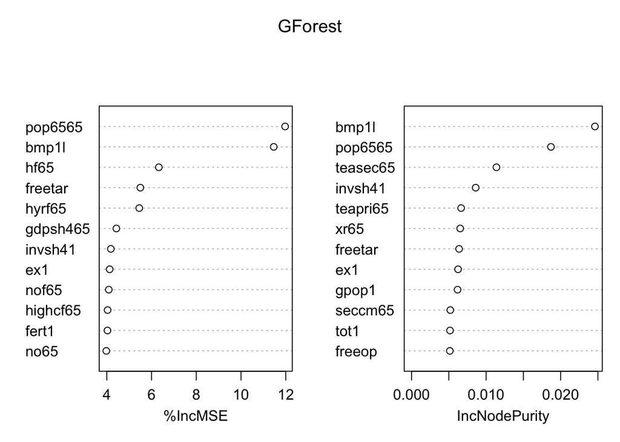

```r
varImpPlot(GForest,n.var=12)
```

* Initial GDP is low on the list * It’s a prediction problem! * Black market premium and population over 65 are high on the list.

### Out of sample with RF

Let’s grow a RF on the training sample:

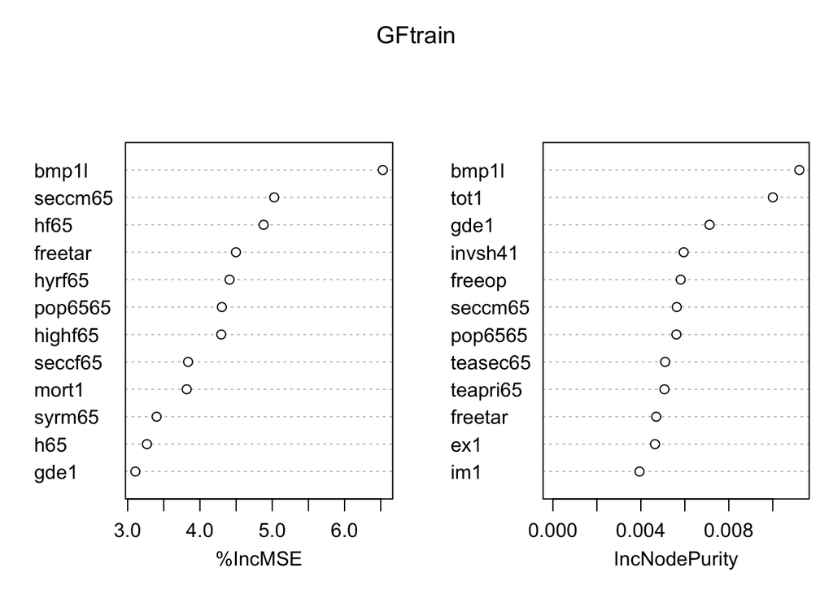

```r
set.seed(42,sample.kind="Reject")
GFtrain<-randomForest(Outcome~.,data=GData[Gtrain,],importance=TRUE)
varImpPlot(GFtrain,n.var=12)
```

* Different variables, but the black market premium is still at the top. * Defense spending has a much lower importance than based on a single tree.

Predict out of sample:

```r
FOutcome.predict<-predict(GFtrain,newdata=GData[-Gtrain,])
MSE.out.G.forest<-mean((FOutcome.predict-outcome.test)^2)/var(outcome.test)
MSE.out.G.forest
```

```
## [1] 0.7855881
```

Summary:

```r
cbind(MSE.out.G.tree,MSE.out.G.lasso,MSE.out.G.forest) %>%
  kable(digits=2,
        caption="Out of sample MSE for Growth Data",
        col.names=c("Tree","Lasso","Random Forest"),
        align=c("c","c","c")) %>%
  kable_classic(full_width = F, html_font = "Cambria")
```

Out of sample MSE for Growth Data

| Tree | Lasso | Random Forest |
| --- | --- | --- |
| 0.98 | 1.25 | 0.79 |

- A much lower prediction error.
- Improvement of 20% (of the variance) relatively to a single tree.

# RF/bagging with Rossi’s arrests data

Let’s grow a RF

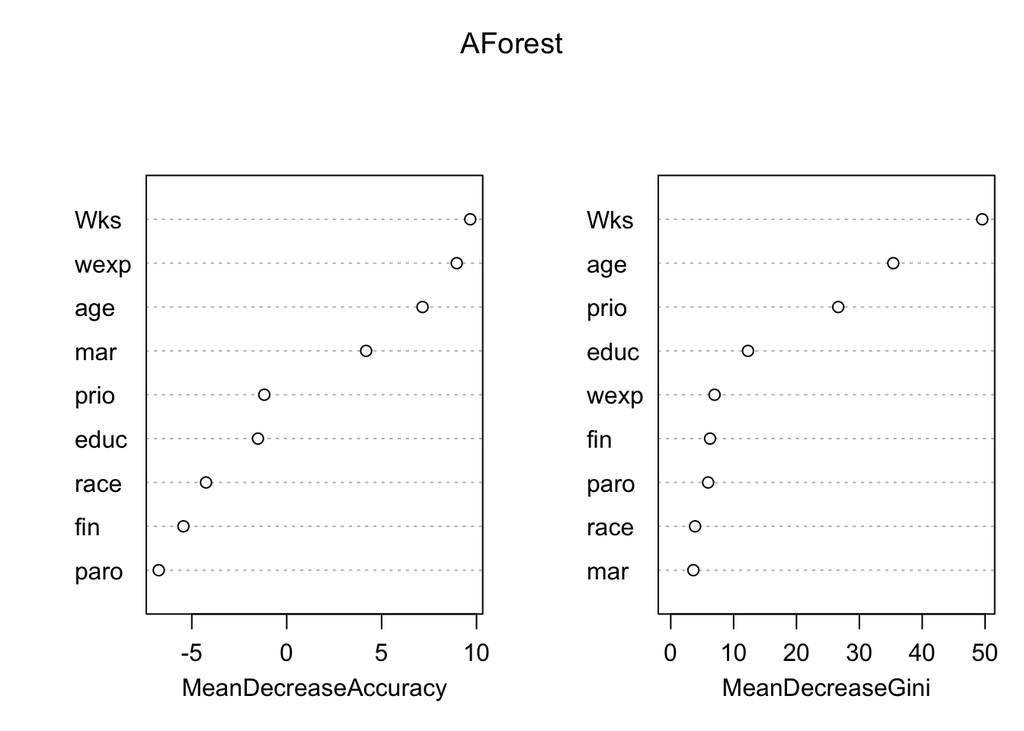

```r
set.seed(42,sample.kind="Reject")
AForest<-randomForest(Arrested~.,data=RData,importance=TRUE)
varImpPlot(AForest)
```

- We see again that `Wks` is at the top.
- There are several other important factors that have not been used in the pruned tree:
  - `age`, `wexp`, `mar`, `prio`.
- The importance of `fin` is low.

### Out of sample

RF on the training sample:

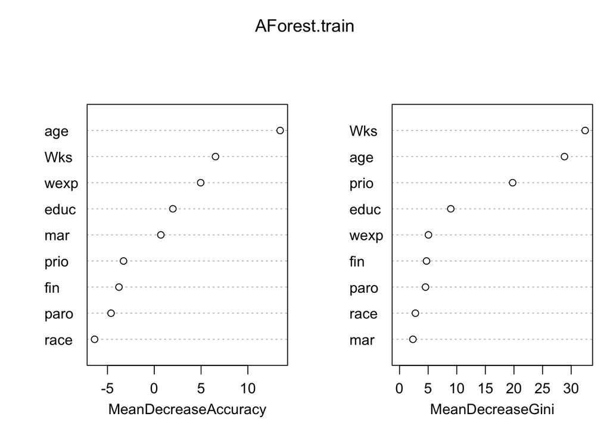

```r
set.seed(42,sample.kind="Reject")
AForest.train<-randomForest(Arrested~.,data=RData[Rtrain,],importance=TRUE)
varImpPlot(AForest.train)
```

- In the training sample, we see again the same factors as being important.

Out of sample

```r
FpredArrest<-predict(AForest.train,newdata=RData[-Rtrain,],type="response")
TAB<-table(predicted=FpredArrest,true=RData$Arrested[-Rtrain])
TAB
```

```
##          true
## predicted no yes
##       no  89  24
##       yes 12   7
```

```r
Error.forest<-(TAB[1,2]+TAB[2,1])/sum(TAB)
Error.forest
```

```
## [1] 0.2727273
```

Summary:

```r
cbind(Error.prunned,Error.unprunned,Error.lasso,Error.forest) %>%
  kable(digits=2,
        caption="Out of sample Error (percentage of missclassified)",
        col.names=c("Prunned tree","Un-prunned tree", "Lasso","Random Forest"),
        align=c("c","c","c","c")) %>%
  kable_classic(full_width = F, html_font = "Cambria")
```

Out of sample Error (percentage of missclassified)

| Prunned tree | Un-prunned tree | Lasso | Random Forest |
| --- | --- | --- | --- |
| 0.32 | 0.3 | 0.23 | 0.27 |

- Lasso is still better as a predictor in this example.
- RF improves relatively to a single tree.
- RF is often best or second best as a predictor.